# Структура научной презентации

## Разложение импульсного сигнала в частичный ряд Фурье

Разложение реализовано с помощью формулы частичного ряда Фурье с синусами и с косинусами.

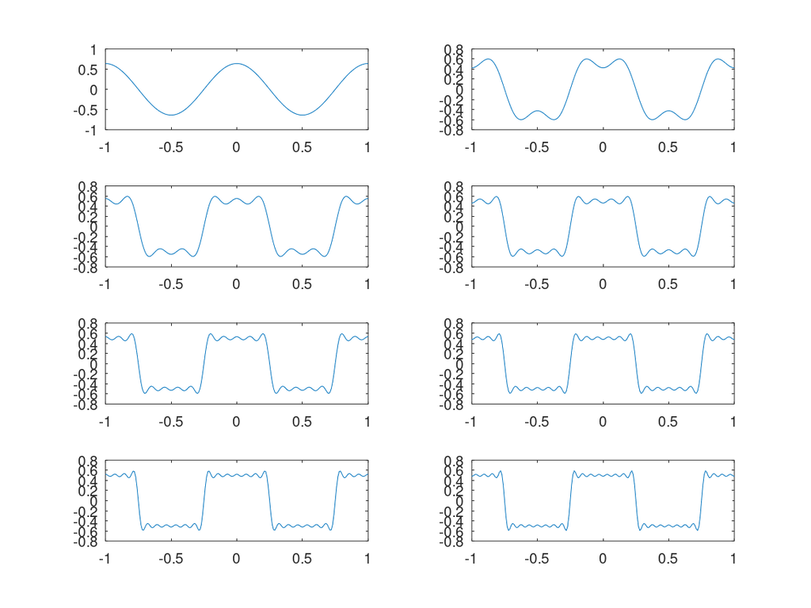

Графики меандра, содержащего различное число гармоник

## Определение спектра и параметров сигнала

**Подзадачи**

- определить спектр двух отдельных сигналов и их суммы
- выполнить задание с другой частотой дискретизации
- узнать, что будет, если взять чистоту дискретизации меньше 80 ГЦ

## Определение спектра и параметров сигнала

- Частота дискретизации: 512 Гц
- Частота первого сигнала: 10 Гц
- Частота второго сигнала: 40 Гц
- Амплитуда первого сигнала: 1
- Амплитуда второго сигнала: 0.7

## Определение спектра и параметров сигнала

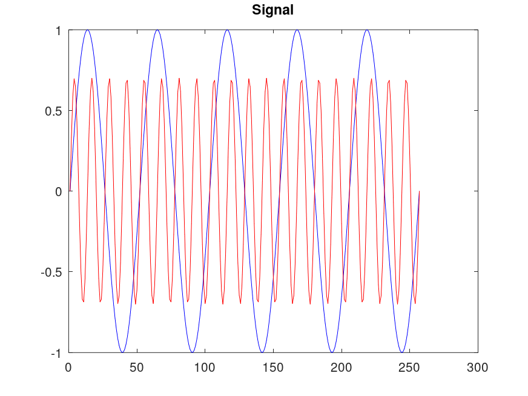

График двух синусоидальных сигналов разной частоты

## Определение спектра и параметров сигнала

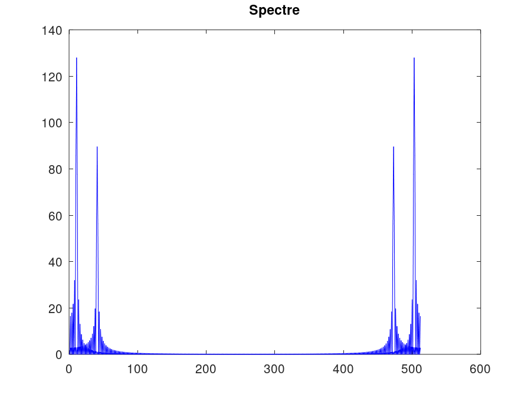

График спектров синусоидальных сигналов

## Определение спектра и параметров сигнала

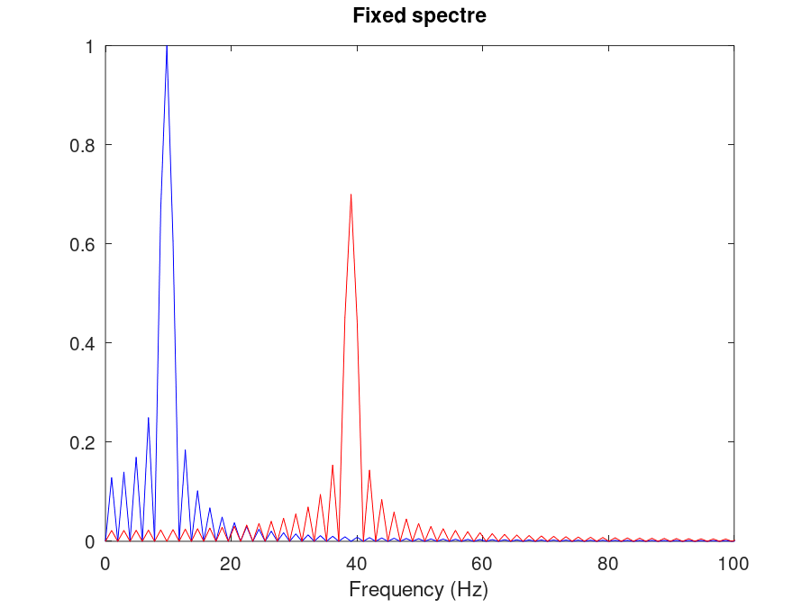

Откорректированный график спектров синусоидальных сигналов

## Определение спектра и параметров сигнала

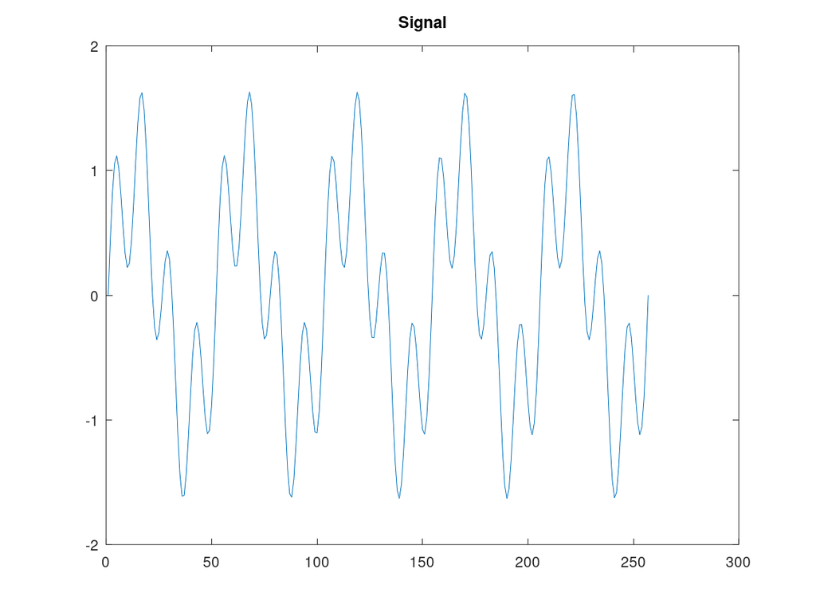

График суммарного сигнала

## Определение спектра и параметров сигнала

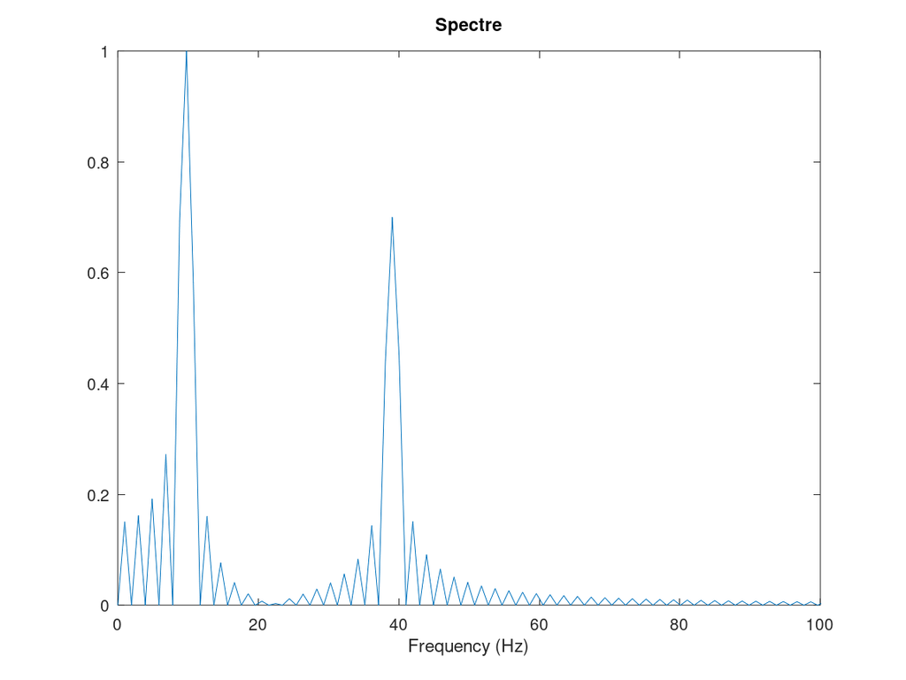

График спектра суммарного сигнала

## Определение спектра и параметров сигнала

Частота дискретизации - 128 ГЦ

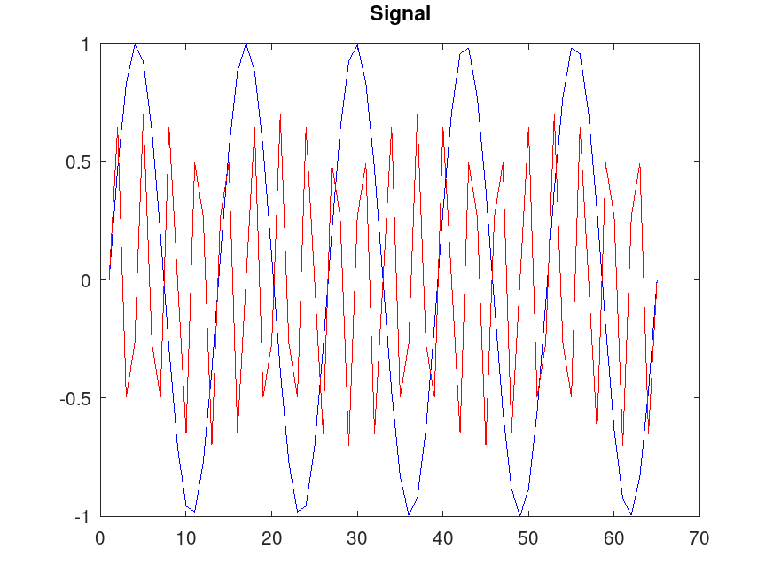

График двух синусоидальных сигналов разной частоты

## Определение спектра и параметров сигнала

Частота дискретизации - 128 ГЦ

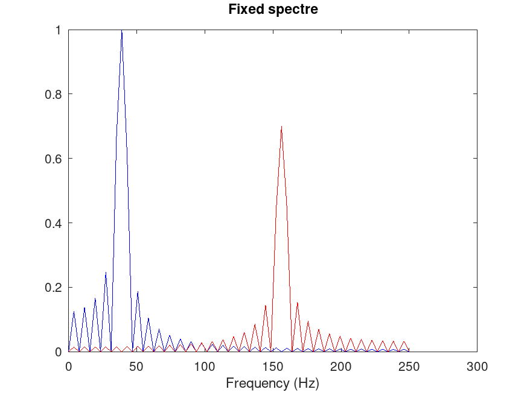

Откорректированнвй график спектров синусоидальных сигналов

## Определение спектра и параметров сигнала

Частота дискретизации - 128 ГЦ

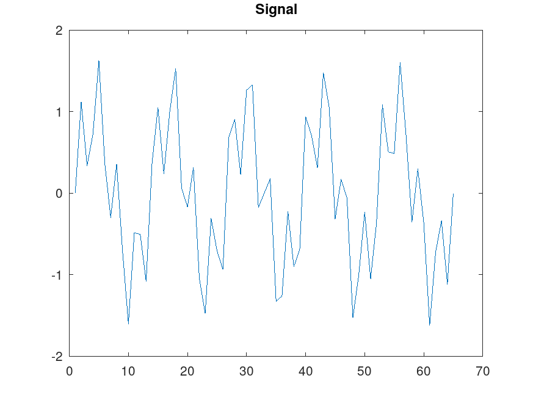

График суммарного сигнала

## Определение спектра и параметров сигнала

Частота дискретизации - 128 ГЦ

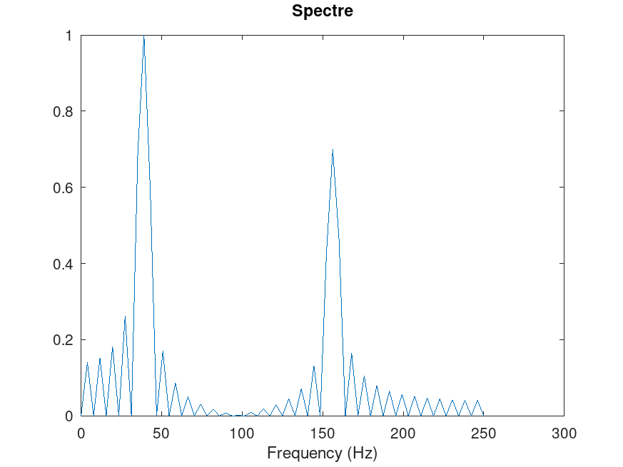

График спектра суммарного сигнала

## Определение спектра и параметров сигнала

Частота дискретизации - 70 ГЦ

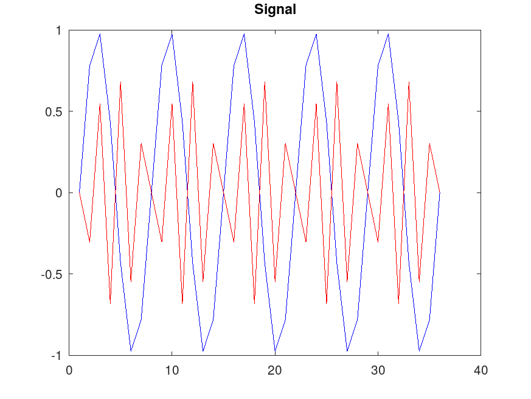

График двух синусоидальных сигналов разной частоты.

## Определение спектра и параметров сигнала

Частота дискретизации - 70 ГЦ

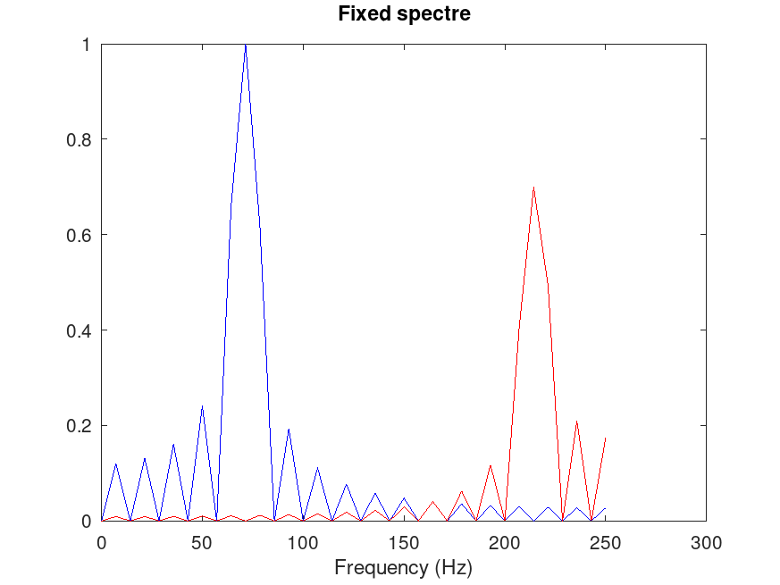

Откорректированнвй график спектров синусоидальных сигналов.

## Определение спектра и параметров сигнала

Частота дискретизации - 70 ГЦ

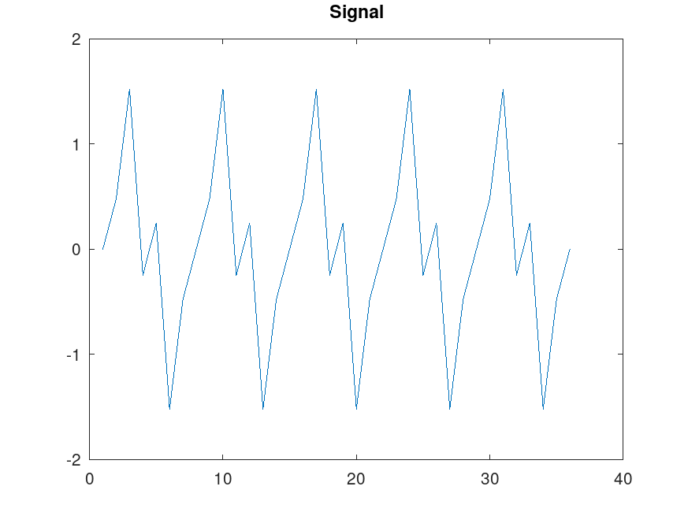

График суммарного сигнала.

## Определение спектра и параметров сигнала

Частота дискретизации - 70 ГЦ

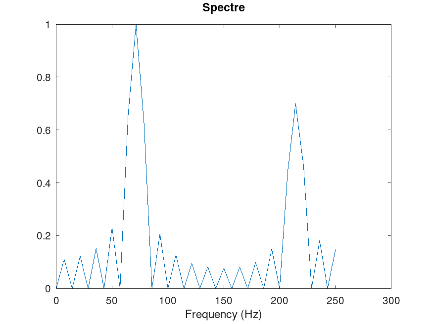

График спектра суммарного сигнала.

## Амплитудная модуляци

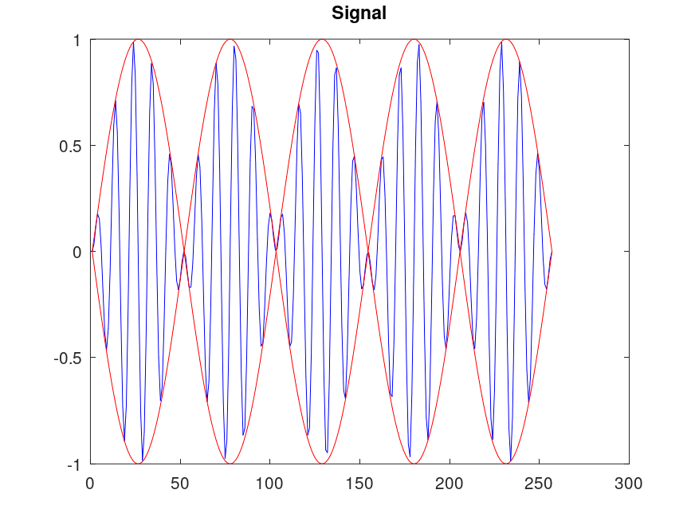

График сигнала и огибающей при амплитудной модуляции

## Амплитудная модуляци

В результате получаем, что спектр произведения представляет собой свёртку спектров

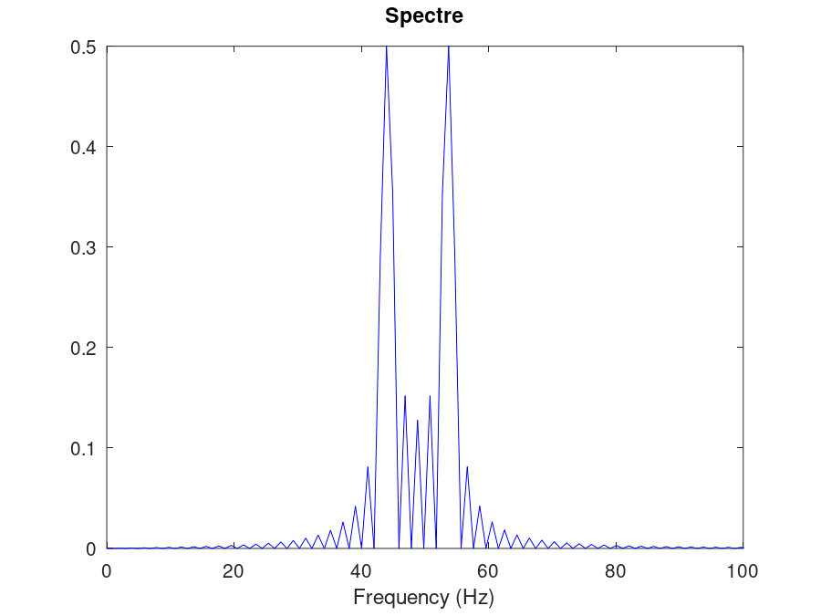

График спектра сигнала при амплитудной модуляции

## Кодирование сигнала. Исследование свойства самосинхронизации сигнала

Входная кодовая последовательность:

- data=[0 1 0 0 1 1 0 0 0 1 1 0]

Входная кодовая последовательность для проверки свойства самосинхронизации:

- data_sync=[0 0 0 0 0 0 0 1 1 1 1 1 1 1]

Входная кодовая последовательность для построения спектра сигнала:

- data_spectre=[0 1 0 1 0 1 0 1 0 1 0 1 0 1]

## Кодирование сигнала. Исследование свойства самосинхронизации сигнала

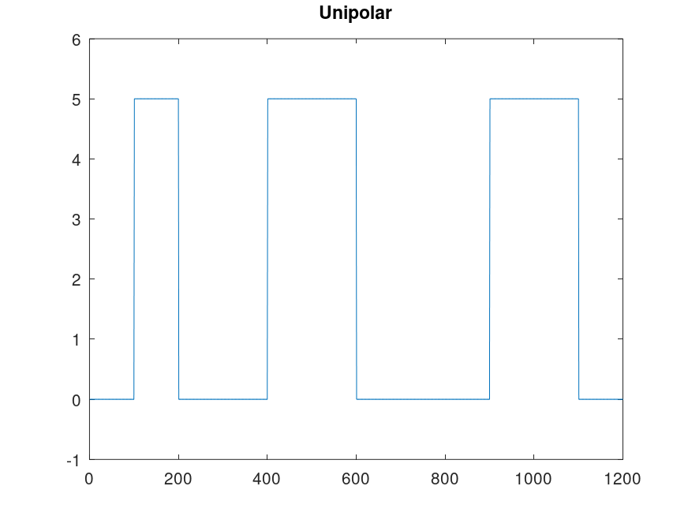

Униполярное кодирование

## Кодирование сигнала. Исследование свойства самосинхронизации сигнала

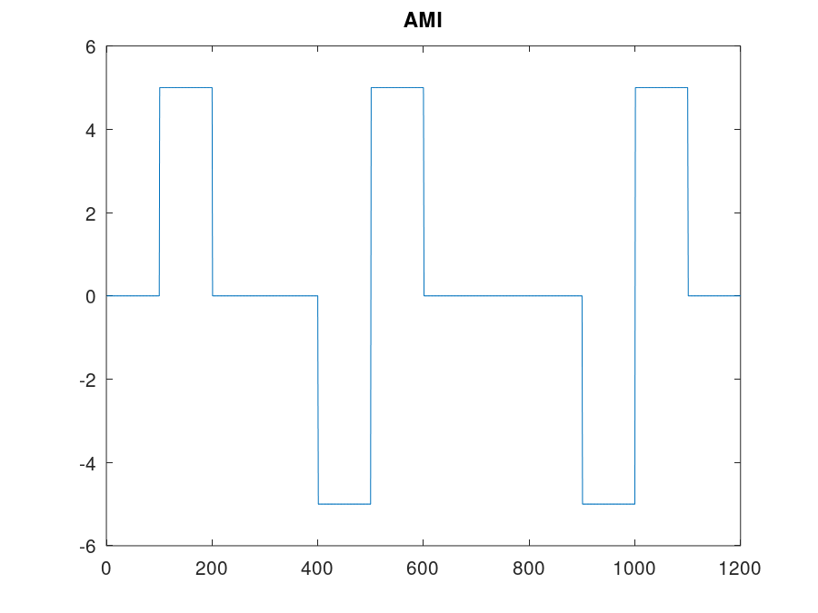

Кодирование AMI

## Кодирование сигнала. Исследование свойства самосинхронизации сигнала

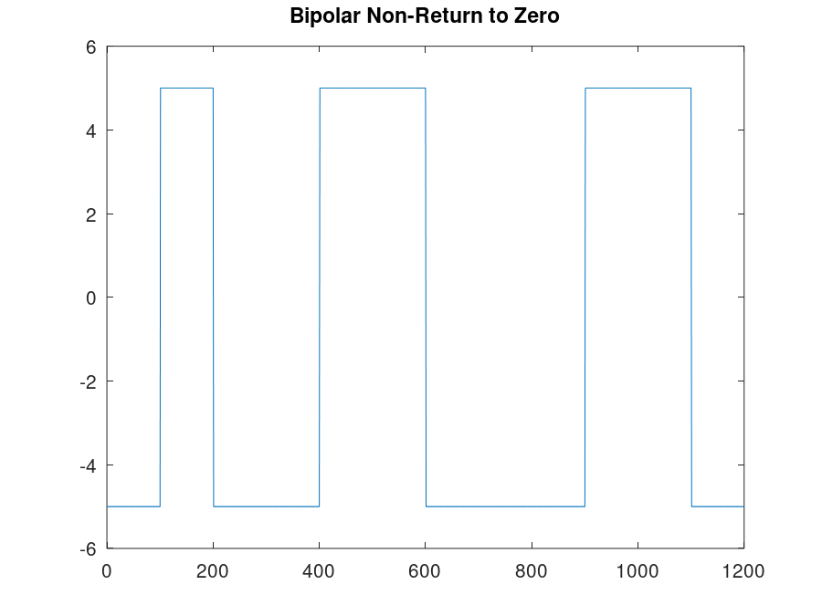

Кодирование NRZ

## Кодирование сигнала. Исследование свойства самосинхронизации сигнала

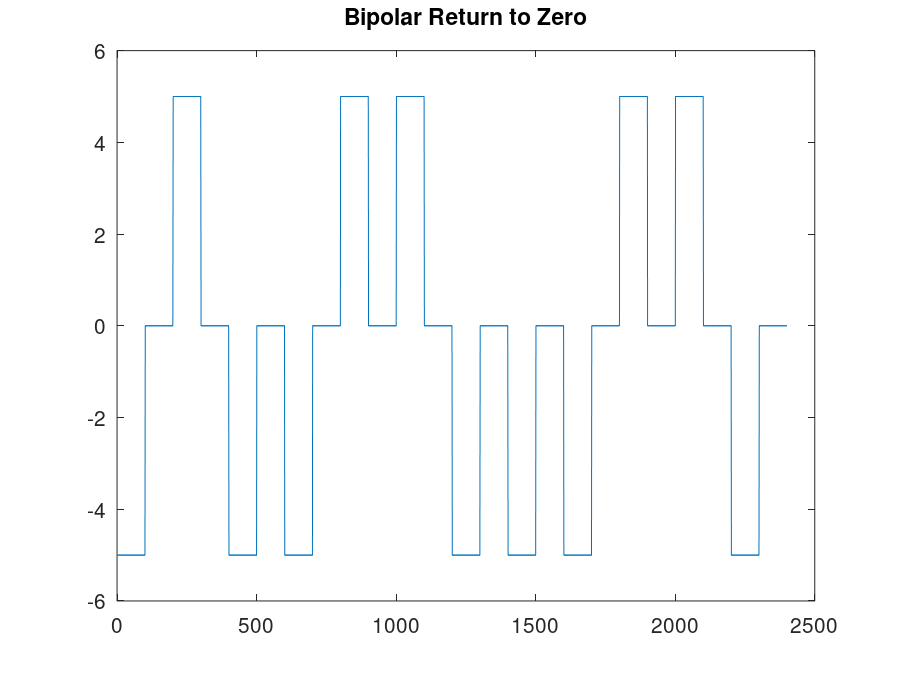

Кодирование RZ

## Кодирование сигнала. Исследование свойства самосинхронизации сигнала

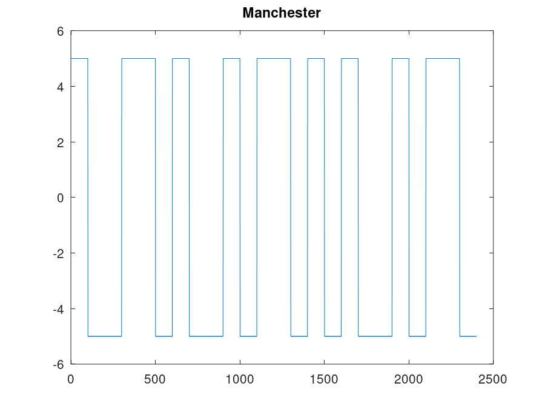

Манчестерское кодирование

## Кодирование сигнала. Исследование свойства самосинхронизации сигнала

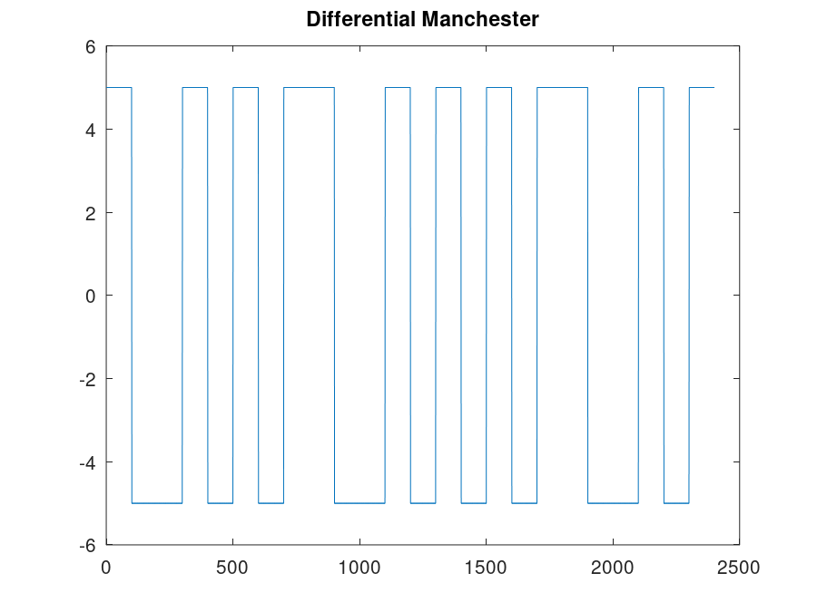

Дифференциальное манчестерское кодирование

## Кодирование сигнала. Исследование свойства самосинхронизации сигнала

[figure not shown]

Униполярное кодирование: нет самосинхронизации

## Кодирование сигнала. Исследование свойства самосинхронизации сигнала

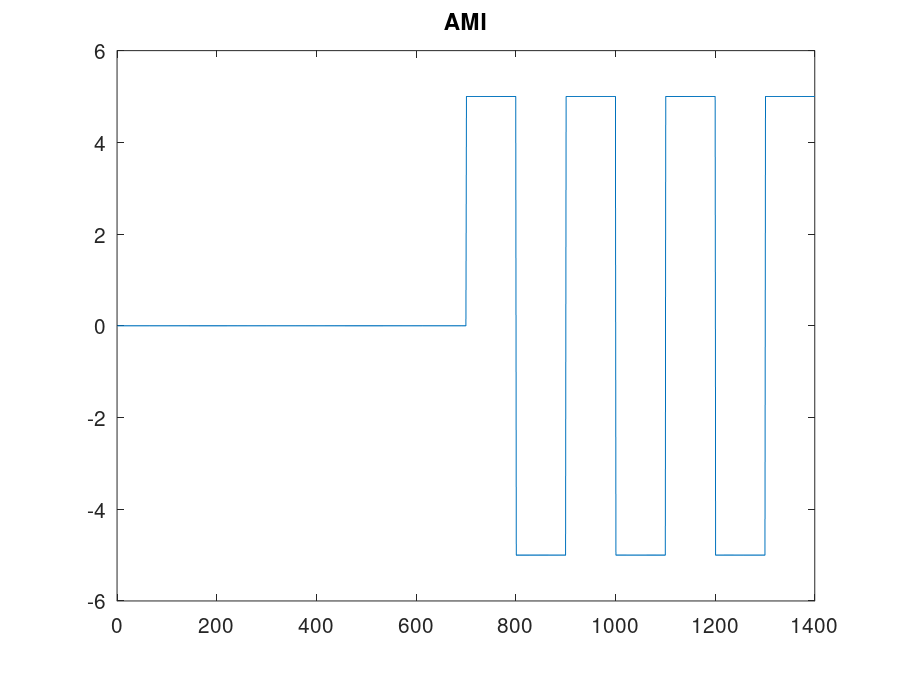

Кодирование AMI: самосинхронизация при наличии сигнала

## Кодирование сигнала. Исследование свойства самосинхронизации сигнала

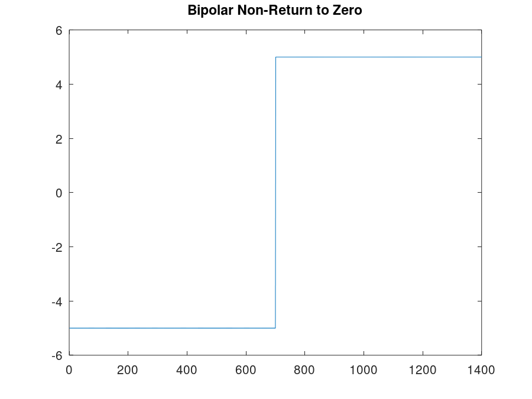

Кодирование NRZ: нет самосинхронизации

## Кодирование сигнала. Исследование свойства самосинхронизации сигнала

[figure not shown]

Кодирование RZ: есть самосинхронизация

## Кодирование сигнала. Исследование свойства самосинхронизации сигнала

[figure not shown]

Манчестерское кодирование: есть самосинхронизация

## Кодирование сигнала. Исследование свойства самосинхронизации сигнала

[figure not shown]

Дифференциальное манчестерское кодирование: есть самосинхронизация

## Кодирование сигнала. Исследование свойства самосинхронизации сигнала

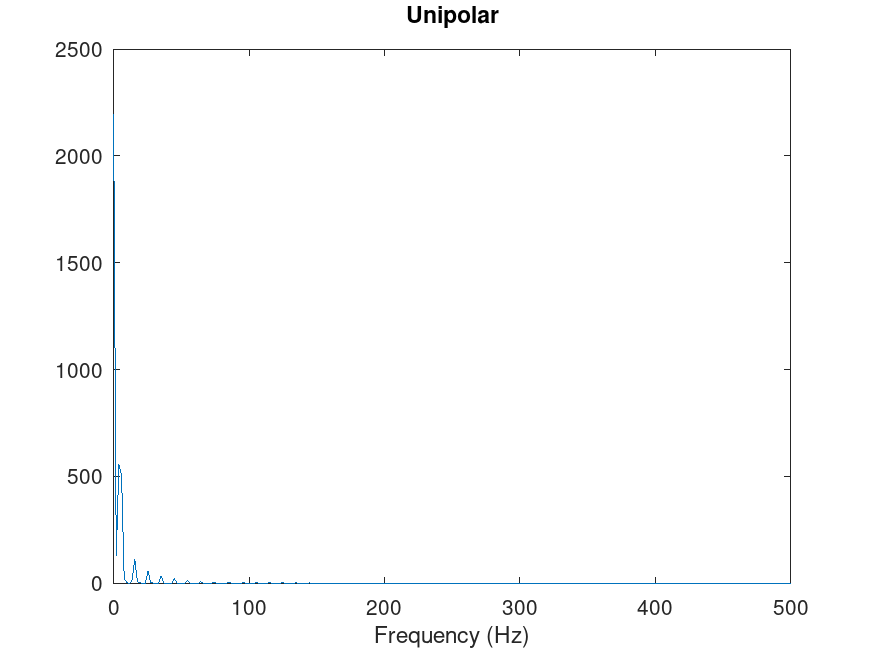

Униполярное кодирование: спектр сигнала